# Daniel Gunther Final Project

Daniel Gunther

4/5/2022

### Exploratory Figures

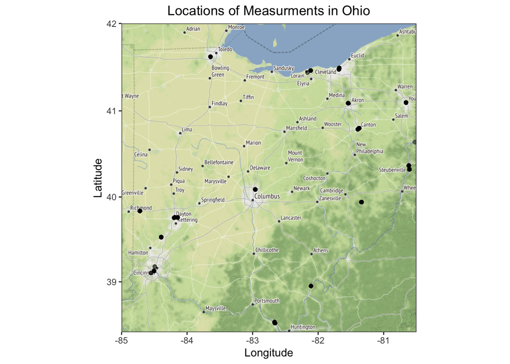

```r
# create geographic paramters of ohio
ohio = c(left = -85, bottom = 38.4, right = -80.5, top = 42)
ohio_map <- get_stamenmap(ohio, zoom = 8, maptype = "terrain")

# locations of where lead was measured since 1970
ggmap(ohio_map)+
  geom_point(data = ohio_data_lead, aes(x = longitude, y = latitude), alpha = 0.01)+
  theme_bw()+
  labs(
    title = "Locations of Measurments in Ohio",
    x = "Longitude",
    y = "Latitude"
  )+
  theme(plot.title = element_text(hjust = 0.5))
```

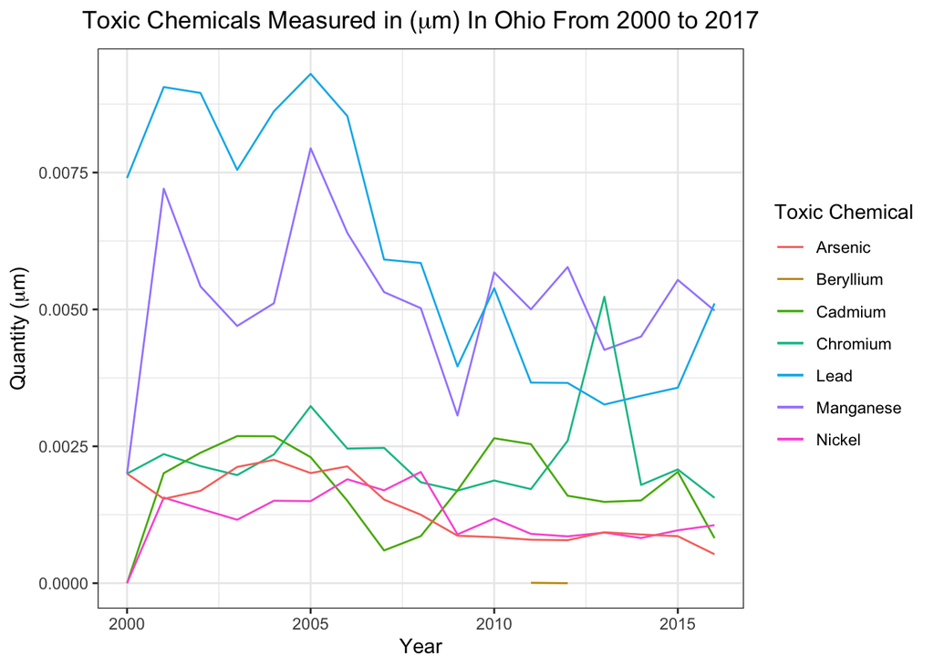

```r
# plot of microgram chemicals by year
ggplot(ohio_microgram_chemicals_by_year)+
  geom_line(aes(x = year, y = mean_manganese, color = "Manganese"))+
  geom_line(aes(x = year, y = mean_chromium, color = "Chromium"))+
  geom_line(aes(x = year, y = mean_cadmium, color = "Cadmium"))+
  geom_line(aes(x = year, y = mean_lead, color = "Lead"))+
  geom_line(aes(x = year, y = mean_nickel, color = "Nickel"))+
  geom_line(aes(x = year, y = mean_arsenic, color = "Arsenic"))+
  geom_line(aes(x = year, y = mean_beryllium, color = "Beryllium"))+
  theme_bw()+
  labs(
    title =  expression("Toxic Chemicals Measured in (" *mu* "m) In Ohio From 2000 to 2017"),
    x = "Year",
    y = expression("Quantity (" *mu* "m)"),
    col = "Toxic Chemical"
  )+
  theme(plot.title = element_text(hjust = 0.5))
```

**Figure 2:** This figure plots the average quantities of chemicals in Ohio’s atmosphere that are measured in micrograms, by year.

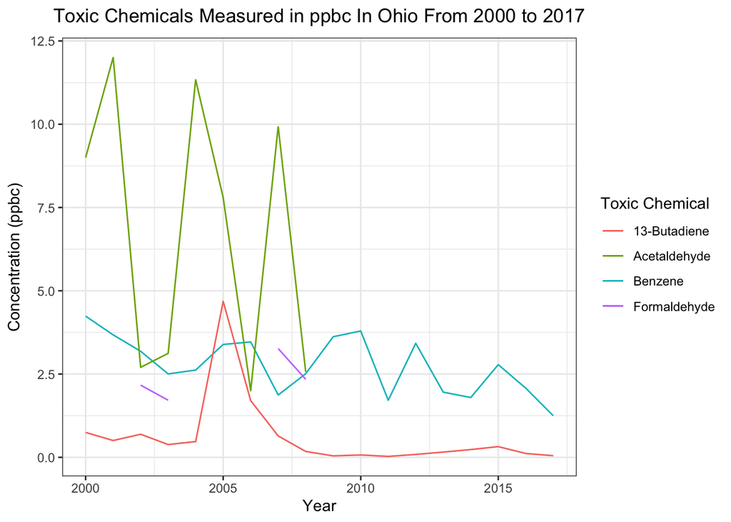

```r
# plot of ppbc with relatively high concentrations
ggplot(ohio_ppbc_chemicals_by_year)+
  geom_line(aes(x = year, y = mean_benzene, color = "Benzene"))+
  geom_line(aes(x = year, y = mean_Acetaldehyde, color = "Acetaldehyde"))+
  geom_line(aes(x = year, y = mean_Formaldehyde, color = "Formaldehyde"))+
  geom_line(aes(x = year, y = mean_13_Butadiene, color = "13-Butadiene"))+
  theme_bw()+
  xlim(2000, 2017)+
  labs(
    title =  expression("Toxic Chemicals Measured in ppbc In Ohio From 2000 to 2017"),
    x = "Year",
    y = expression("Concentration (ppbc)"),
    col = "Toxic Chemical"
  )+
  theme(plot.title = element_text(hjust = 0.5))
```

**Figure 3:** This figure plots the average quantities of chemicals in Ohio’s atmosphere that are measured in parts per billion carbon, with relatively high concentrations, by year.

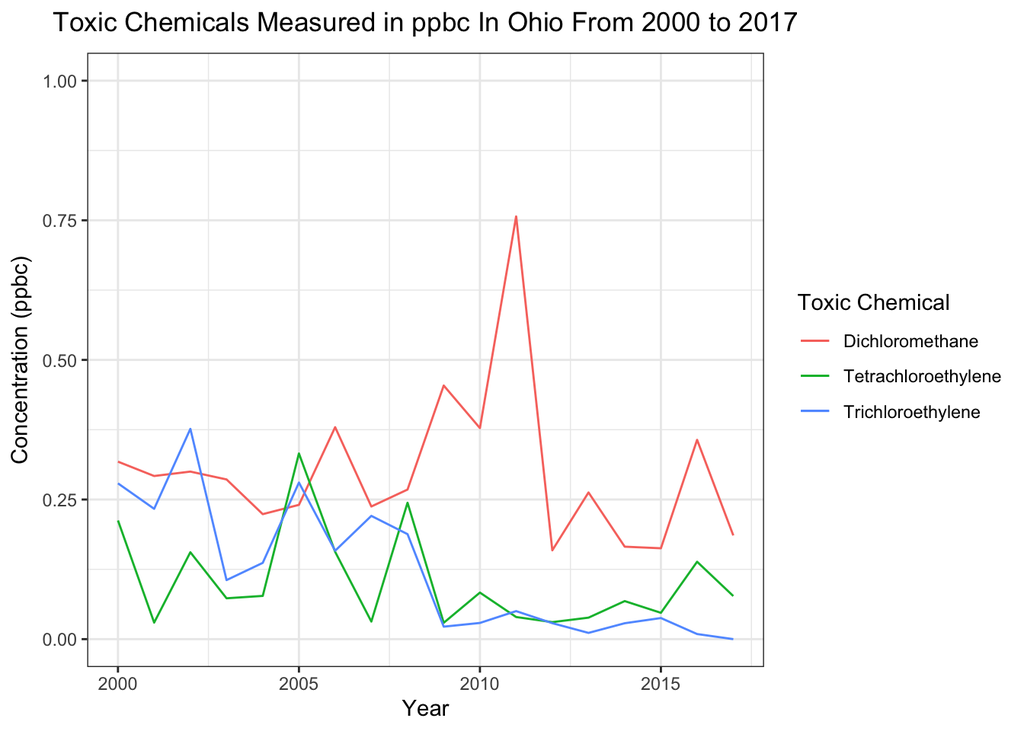

```r
# plot of ppbc with mid ranged concentrations
ggplot(ohio_ppbc_chemicals_by_year)+
  geom_line(aes(x = year, y = mean_Dichloromethane, color = "Dichloromethane"))+
  geom_line(aes(x = year, y = mean_Tetrachloroethylene, color = "Tetrachloroethylene"))+
  geom_line(aes(x = year, y = mean_Trichloroethylene, color = "Trichloroethylene"))+
  theme_bw()+
  ylim(0, 1)+
  xlim(2000, 2017)+
  labs(
    title =  expression("Toxic Chemicals Measured in ppbc In Ohio From 2000 to 2017"),
    x = "Year",
    y = expression("Concentration (ppbc)"),
    col = "Toxic Chemical"
  )+
  theme(plot.title = element_text(hjust = 0.5))
```

**Figure 4:** This figure plots the average quantities of chemicals in Ohio’s atmosphere that are measured in parts per billion carbon, with mid-ranged concentrations, by year.

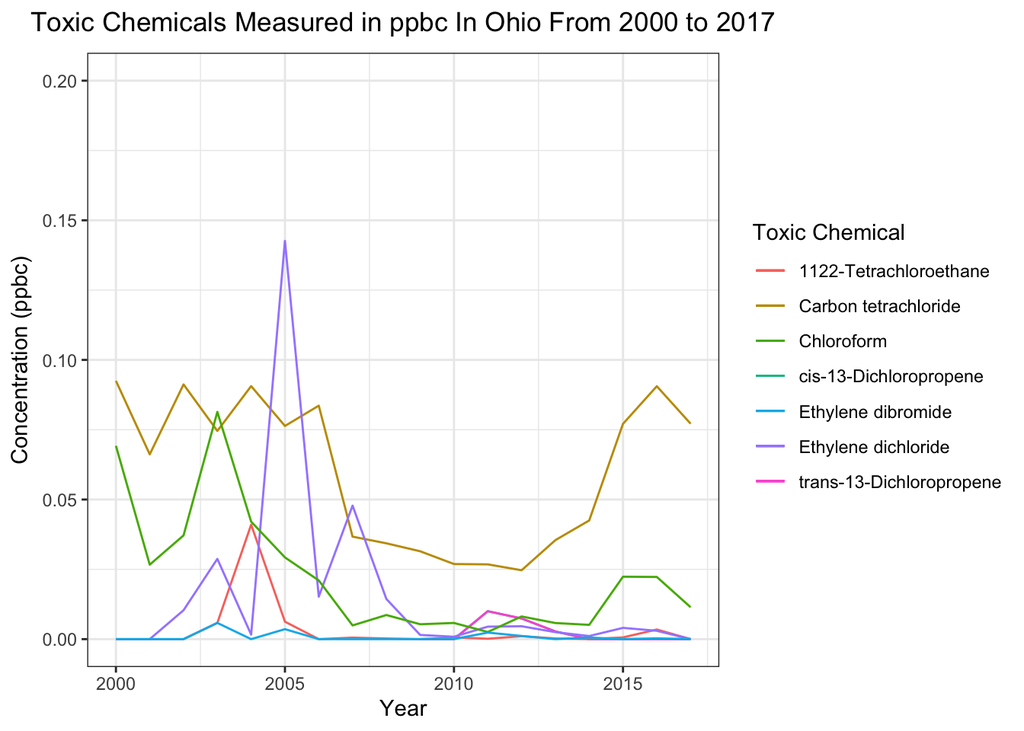

```r
# plot of relatively low ppbc chemicals by year
ggplot(ohio_ppbc_chemicals_by_year)+
  geom_line(aes(x = year, y = mean_cis_13_Dichloropropene, color = "cis-13-Dichloropropene"))+
  geom_line(aes(x = year, y = mean_Carbon_tetrachloride, color = "Carbon tetrachloride"))+
  geom_line(aes(x = year, y = mean_cis_13_Dichloropropene, color = "trans-13-Dichloropropene"))+
  geom_line(aes(x = year, y = mean_1122_Tetrachloroethane, color = "1122-Tetrachloroethane"))+
  geom_line(aes(x = year, y = mean_Ethylene_dichloride, color = "Ethylene dichloride"))+
  geom_line(aes(x = year, y = mean_Chloroform, color = "Chloroform"))+
  geom_line(aes(x = year, y = mean_Ethylene_dibromide, color = "Ethylene dibromide"))+
  theme_bw()+
  ylim(0, 0.2)+
  xlim(2000, 2017)+
  labs(
    title =  expression("Toxic Chemicals Measured in ppbc In Ohio From 2000 to 2017"),
    x = "Year",
    y = expression("Concentration (ppbc)"),
    col = "Toxic Chemical"
  )+
  theme(plot.title = element_text(hjust = 0.5))
```

**Figure 5:** This figure plots the average quantities of chemicals in Ohio’s atmosphere that are measured in parts per billion carbon, with relatively low concentrations, by year.

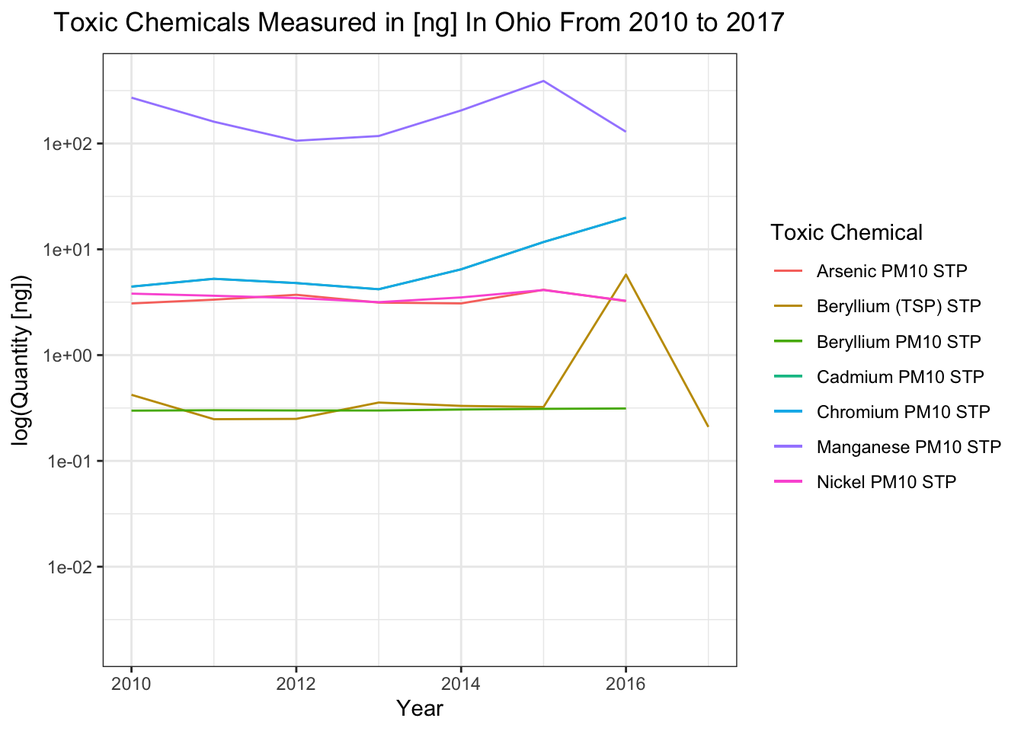

```r
# plot of nanogram chemicals by year
ggplot(ohio_nano_chemicals_by_year)+
  geom_line(aes(x = year, y = mean_ber, color = "Beryllium (TSP) STP"))+
  geom_line(aes(x = year, y = mean_small_mang, color = "Manganese PM10 STP"))+
  geom_line(aes(x = year, y = mean_small_chromium, color = "Cadmium PM10 STP"))+
  geom_line(aes(x = year, y = mean_small_arsenic, color = "Arsenic PM10 STP"))+
  geom_line(aes(x = year, y = mean_small_chromium, color = "Chromium PM10 STP"))+
  geom_line(aes(x = year, y = mean_small_nickel, color = "Nickel PM10 STP"))+
  geom_line(aes(x = year, y = mean_tiny_beryllium, color = "Beryllium PM10 STP"))+
  scale_y_log10()+
  xlim(2010, 2017)+
  theme_bw()+
  labs(
    title =  expression("Toxic Chemicals Measured in [ng] In Ohio From 2010 to 2017"),
    x = "Year",
    y = expression("log(Quantity [ng])"),
    col = "Toxic Chemical"
  )+
  theme(plot.title = element_text(hjust = 0.5))
```

**Figure 6:** This figure plots the average quantities of chemicals in Ohio’s atmosphere that are measured in nano grams, by year. Note that the y-axis is a log base 10 axis.

### Statistical Tests Investigating Quantity Spikes

```r
# t-test comparing ethylene dichloride values in 2005 versus the average
ethylene_dichloride_2005 <- ohio_ppbc_chemicals_by_year %>%
  filter(year == 2005)
```

```r
# t-test comparing mean ethylene dichloride and the value in 2005
t.test(ohio_ppbc_chemicals_by_year$mean_Ethylene_dichloride, mu = ethylene_dichloride_2005$mean_Ethylene_dichloride)
```

```
##
##  One Sample t-test
##
## data:  ohio_ppbc_chemicals_by_year$mean_Ethylene_dichloride
## t = -7.0987, df = 19, p-value = 9.432e-07
## alternative hypothesis: true mean is not equal to 0.1426087
## 95 percent confidence interval:
##  -0.004315273  0.062596294
## sample estimates:
##  mean of x
## 0.02914051
```